# The Anatomy of an Answer

Gerko Vink

g.vink@uu.nl

Methodology & Statistics @ Utrecht University

15 Jun 2026

## Disclaimer

I owe a debt of gratitude to many people as the thoughts and code in these slides are the process of years-long development cycles and discussions with my team, friends, colleagues and peers. When someone has contributed to the content of the slides, I have credited their authorship.

Scientific references are in the footer. Opinions and figures are my own, AI-generated or directly linked.

**Materials**

- source: github.com/gerkovink/mod12
- website: www.gerkovink.com/mod12

## Schema van de cursus

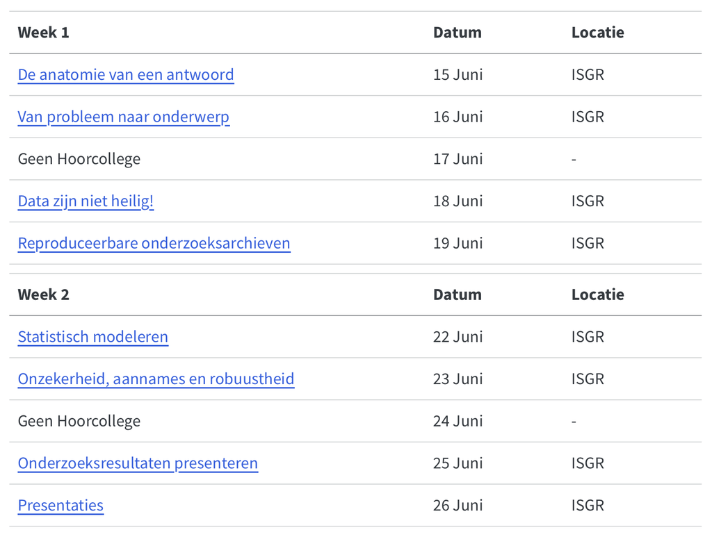

## Becijfering

Het eindcijfer van de module wordt als volgt vastgesteld:

- Research Project Report: 85%
- Persoonlijke reflectie op de cursus, het proces en de samenwerking met medestudenten: 5%
- Mondelinge presentatie: 10%

## Terms I may use

- TDGM: True data generating model
- DGP: Data generating process, closely related to the TDGM, but with all the wacky additional uncertainty
- Truth: The comparative truth that we are interested in
- Bias: The distance to the comparative truth
- Variance: When not everything is the same
- Estimate: Something that we calculate or guess
- Estimand: The thing we aim to estimate and guess
- Population: That larger entity without sampling variance
- Sample: The smaller thing with sampling variance
- Incomplete: There exists a more complete version, but we don’t have it
- Observed: What we have
- Unobserved: What we would also like to have

## At the start

Let’s start with the core:

**Statistical inference**

Statistical inference is the process of drawing conclusions from **truths**

Truths are boring, but they are convenient.

- however, for most problems truths require a lot of calculations, tallying or a complete census.
- therefore, a proxy of the truth is in most cases sufficient
- An example for such a proxy is a **sample**
- Samples are widely used and have been for a long time$^1$

$^1$ See Jelke Bethlehem’s CBS discussion paper for an overview of the history of survey sampling

## Do we need data?

Without any data we can still come up with a statistically valid answer.

- The answer will not be very *informative*.
- In order for our answer to be more informative, we need more **information**

Some sources of information can already tremendously guide the precision of our answer.

**In Short**

Information bridges the answer to the truth. Too little information may lead you to a *false truth*.

## Being wrong about the truth

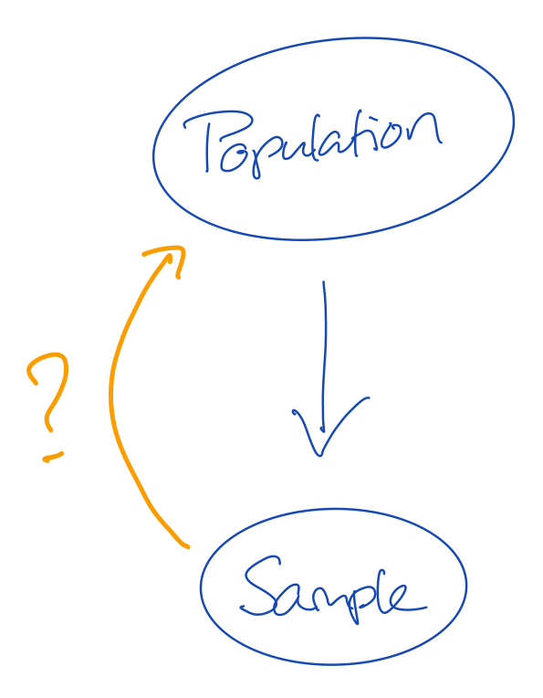

- The population is the truth
- The sample comes from the population, but is generally smaller in size
- This means that not all cases from the population can be in our sample
- If not all information from the population is in the sample, then our sample may be *wrong*

**Good questions to ask yourself**

1. Why is it important that our sample is not wrong?
2. How do we know that our sample is not wrong?

## Solving the missingness problem

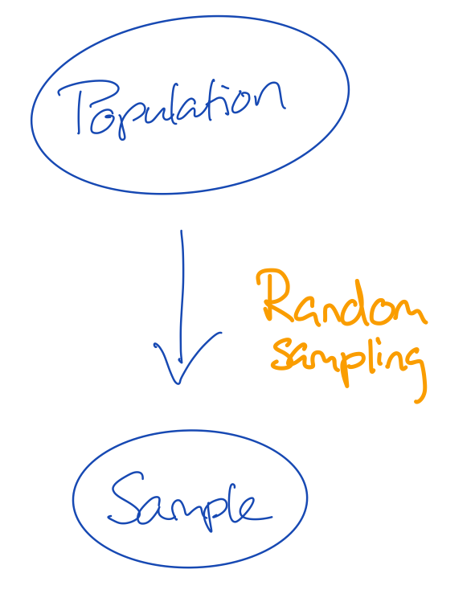

- There are many flavours of sampling
- If we give every unit in the population the same probability to be sampled, we do **random sampling**
- The convenience with random sampling is that the missingness problem can be ignored
- The missingness problem would in this case be: **not every unit in the population has been observed in the sample**

**Hmmm…**

Would that mean that if we simply observe every potential unit, we would be unbiased about the truth?

## Sidestep

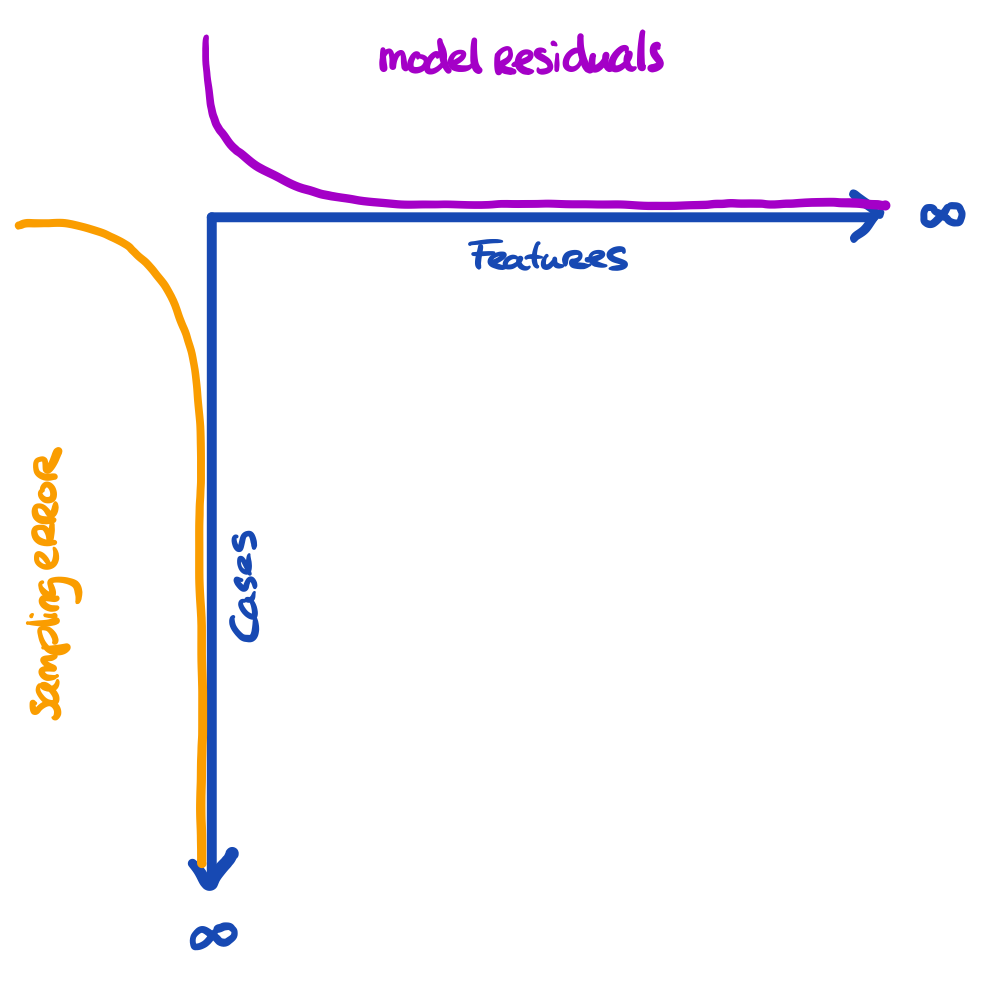

- The problem is a bit larger
- We have three entities at play, here:
  1. The truth we’re interested in
  2. The proxy that we have (e.g. sample)
  3. The model that we’re running
- The more features we use, the more we capture about the outcome for the cases in the data
- The more cases we have, the more we approach the true information  
  All these things are related to uncertainty. Our model can still yield biased results when fitted to $\infty$ features. Our inference can still be wrong when obtained on $\infty$ cases.

## Sidestep

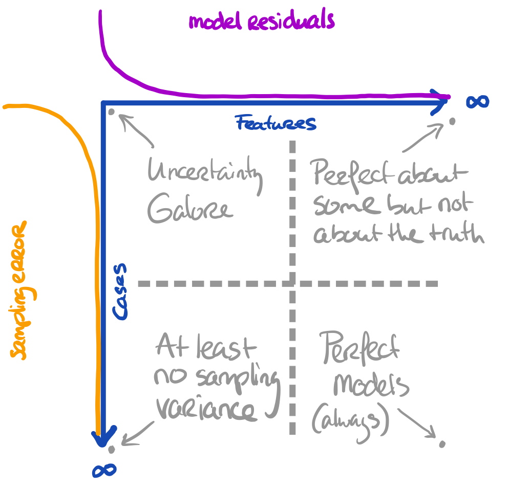

- The problem is a bit larger
- We have three entities at play, here:
  1. The truth we’re interested in
  2. The proxy that we have (e.g. sample)
  3. The model that we’re running
- The more features we use, the more we capture about the outcome for the cases in the data
- The more cases we have, the more we approach the true information

**Core assumption: all observations are bonafide**

## Uncertainty simplified

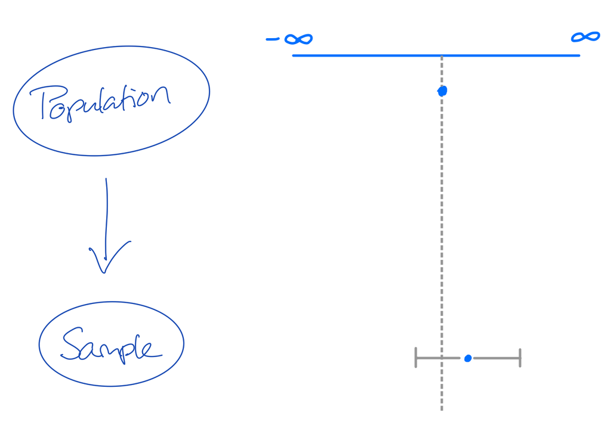

When we do not have all information …

1. We need to accept that we are probably wrong
2. We just have to quantify how wrong we are

In some cases we estimate that we are only a bit wrong. In other cases we estimate that we could be very wrong. This is the purpose of testing.  
The uncertainty measures about our estimates can be used to create intervals

## Confidence in the answer

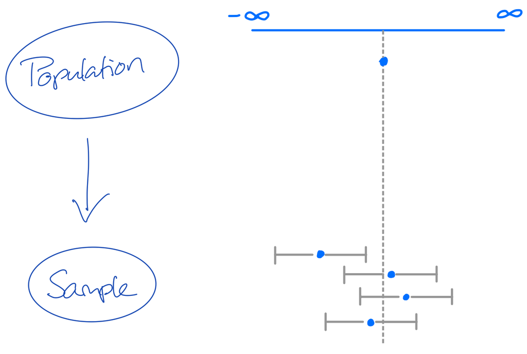

An intuitive approach to evaluating an answer is confidence. In statistics, we often use confidence intervals. Discussing confidence can be hugely informative!

- If the coverage <95: bad estimation process with risk of errors and invalid inference
- If the coverage >95: inefficient estimation process, but correct conclusions and valid inference. Lower statistical power.

Neyman, J. (1934). On the Two Different Aspects of the Representative Method: The Method of Stratified Sampling and the Method of Purposive Selection.  
Journal of the Royal Statistical Society Series A: Statistics in Society, 97(4), 558-606.

## How do we know that our sample is not….

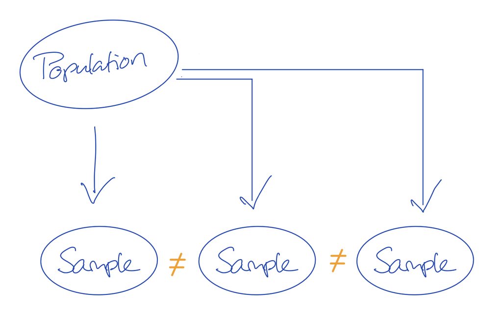

We can replicate our sample.

- A replication would be a new sample from the same population or true data generating model obtained by the same data generating process.
- If we would sample 100 times, we would get 100 different samples
- If we would estimate 100 times, we would get 100 different estimates with 100 different confidence intervals (e.g. 95% CI)
- Out of these 100 different intervals, we would expect a nominal coverage. For a 95% CI we’d expect 95 of them to cover the true population value.

## This is a lot of work…

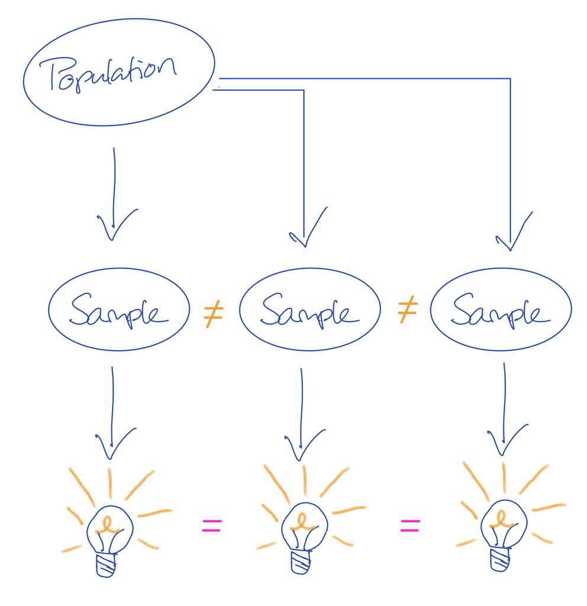

Full sampling validation of a model’s inferences is a lot of work.

- it is the most robust way of obtaining inferential validity
- it is not always necessary

Under some general assumptions, we can use the same data to validate our model’s inferences and predictions.

- these assumptions can be met in practice
- but as soon as assumptions are made, we open the door to errors when these assumptions do not hold

## Assumptions

Take the following definition:

**a thing that is accepted as true or as certain to happen, without proof.**

Assumptions are a statisticians faith. It is often impossible to prove that they hold in practice, but we choose to believe that they do.

**Sensitivity analyses**

I often use computational evaluation techniques to quantify the scope of the impact of assumptions made. For example, we can test the effect of violating assumptions on our results. We then verify if the inferences are sensitive to violations of the assumptions. We can even verify the extend of when assumptions start becoming influential to our inferences.

## The holy trinity

Whenever I evaluate something, I tend to look at three things:

- bias (how far from the truth)
- uncertainty/variance (how wide is my interval)
- coverage (how often do I cover the truth with my interval)

As a function of model complexity in specific modeling efforts, these components play a role in the bias/variance tradeoff

[figure not shown]

## On the individual level

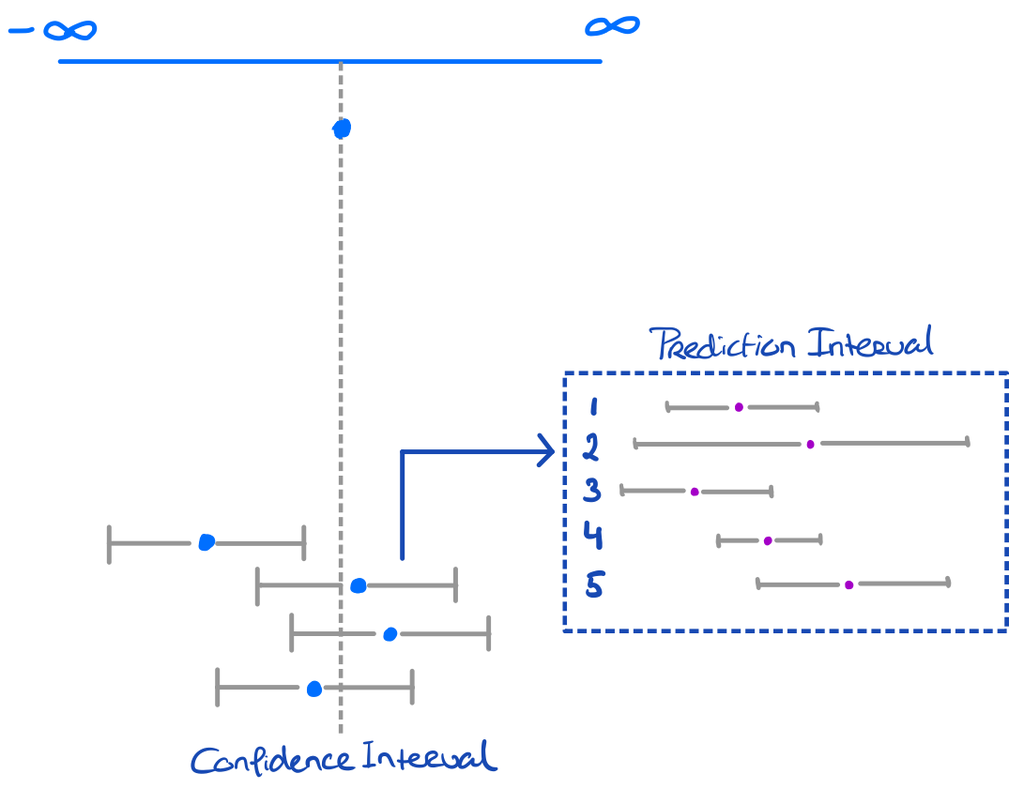

Individual intervals can also be hugely informative!

Individual intervals are generally wider than confidence intervals

- This is because it covers inherent uncertainty in the data point on top of sampling uncertainty

**Be careful**

Narrower intervals mean less uncertainty.

It does not mean that the answer is correct!

## Case: Spaceshuttle Challenger

[figure not shown]

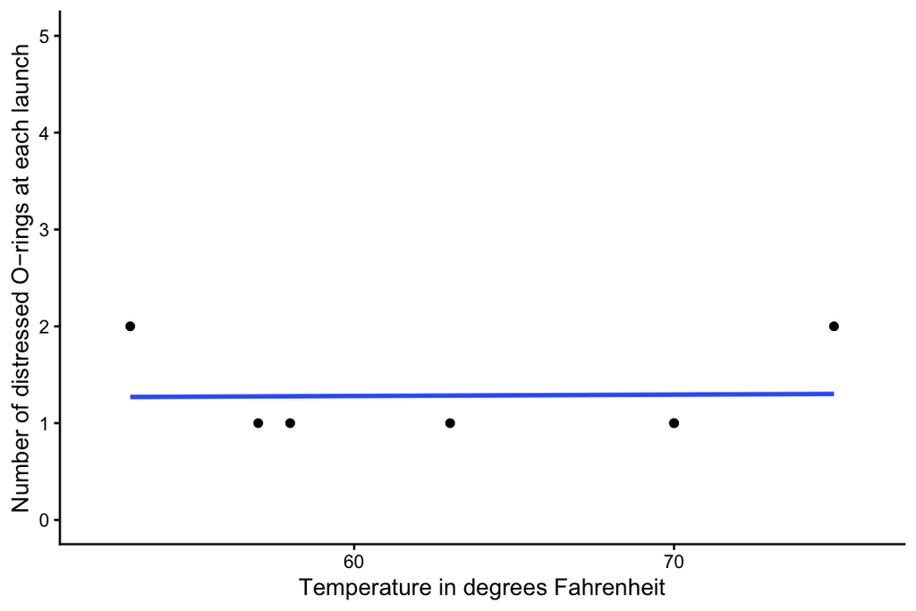

## Nothing happened, so we ignored it

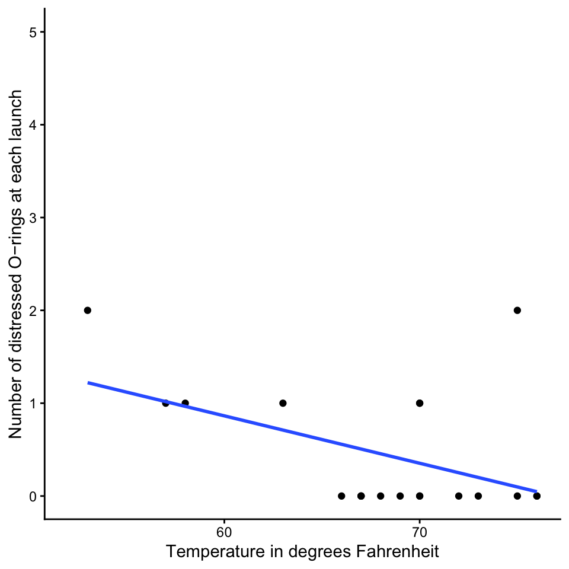

In the decision to proceed with the launch, there was a presence of dark data. And no-one noticed!

**Dark data**

Information that is not available but necessary to arrive at the correct answer.

This missing information has the potential to mislead people. The notion that we can be misled is essential because it also implies that artificial intelligence can be misled!

If you don’t have all the information, there is always the possibility of drawing an incorrect conclusion or making a wrong decision.

## In Practice

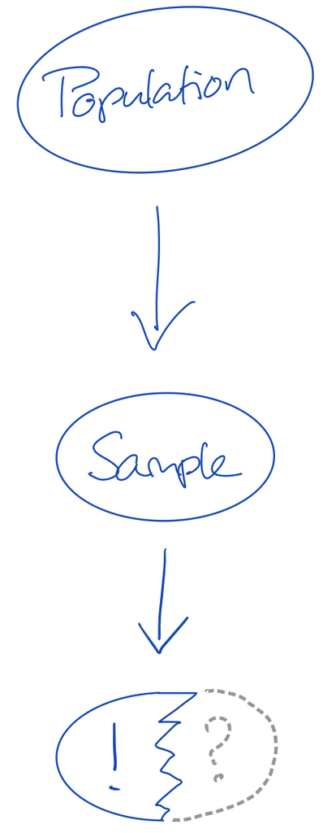

We now have a new problem:

- we do not have the whole truth; but merely a sample of the truth
- we do not even have the whole sample, but merely a sample of the sample of the truth.

What would be a simple solution to allowing for valid inferences on the incomplete sample? Would that solution work in practice?

## How to fix the missingness problem

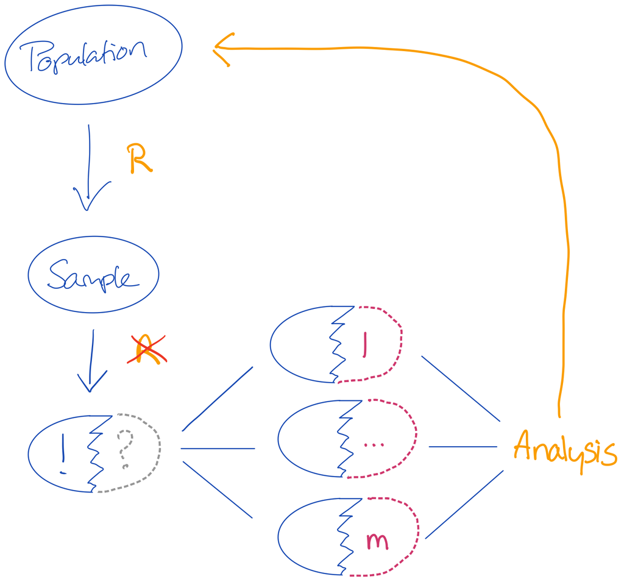

There are two sources of uncertainty that we need to cover when analyzing incomplete data:

1. **Uncertainty about the data values we don’t have**:  
   when we don’t know what the true observed value should be, we must create a distribution of values with proper variance (uncertainty).
2. **Uncertainty about the process that generated the values we do have**:  
   nothing can guarantee that our sample is the one true sample. So it is reasonable to assume that the parameters obtained on our sample are biased.

A straightforward and intuitive solution for analyzing incomplete data in such scenarios is *multiple imputation* (Rubin, 1987).

Rubin, D. B. (1987). Multiple imputation for nonresponse in surveys. John Wiley & Sons.

## Now how do we know we did well?

**I’m really sorry!**

In practice we don’t know if we did well, because we often lack the necessary comparative truths.

For example:

1. Predict a future response, but we only have the past
2. Analyzing incomplete data without a reference about the truth
3. Estimate the effect between two things that can never occur together
4. Detecting fraudulent transactions with only access to the own transaction history
5. Appealing to a new customer base with only data about existing customers
6. Mixing bonafide observations with bonafide non-observations

# Wat is dan de anatomie van een antwoord?

## De anatomie van een antwoord

Een statistisch antwoord is meer dan een getal, tabel of modeloutput.

**Een goed antwoord**

Een goed antwoord verbindt een **vraag**, een **databron**, een **methode**, een **claim** en houdt in het hele proces rekening met **beperkingen**.

Daarom vragen we steeds:

1. Wat willen we weten?
2. Welke data kunnen daarover iets zeggen?
3. Welke vergelijking of schatting is nodig?
4. Welke aannames maken we?
5. Wat mogen we wel en niet concluderen?

> Het is daarbij ook heel belangrijk om regelmatig met alle stakeholders in een onderzoek rond de tafel te gaan zitten.

## Waarom statistische antwoorden falen

Statistische antwoorden falen vaak niet omdat de software kapot is!

Ze falen omdat:

- de vraag te vaag is
- de data niet passen bij de vraag
- de methode niet past bij het design
- belangrijke informatie ontbreekt
- de interpretatie sterker is dan de analyse toelaat
- beperkingen pas achteraf worden genoemd.
- niet alle betrokken stakeholders ook echt betrokken zijn in het hele proces

> **Een model kan geen onduidelijke vraag repareren!**

## Antwoord of output?

### Output

- een regressietabel
- een p-waarde
- een grafiek
- een gemiddelde
- een classificatie
- een AI-samenvatting

### Antwoord

- gericht op een vraag
- gekoppeld aan data
- onderbouwd met methode
- begrensd door aannames
- voorzichtig geïnterpreteerd
- bruikbaar voor besluitvorming

Welke output heb je in jouw project nodig om de vraag te kunnen beantwoorden?

## Van onderwerp naar onderzoeksvraag

Een onderwerp is nog geen onderzoeksvraag.

| Breed onderwerp | Onderzoekbare vraag |
| --- | --- |
| Wateroverlast in Suriname | In welke mate is gerapporteerde wateroverlast onder huishoudens geassocieerd met afwatering, locatie en sociaaleconomische kenmerken? |
| Corruptie en vertrouwen | In welke mate hangen corruptiepercepties samen met vertrouwen in overheidsinstellingen? |
| Taal en rekenprestaties | In welke mate voorspelt Nederlandse taalvaardigheid rekenprestaties, gecontroleerd voor achtergrondkenmerken? |

**Vuistregel**

Een onderzoeksvraag houdt rekening met minimaal: **populatie**, **uitkomst**, **verklarende variabele of vergelijking**, **context**, **data** en **claim**.

## Claim boundaries

Let er op dat statistiek het domein van wiskunde is waar we probability density functies moeten gebruiken om een antwoord te formuleren.

> Taal maakt het verschil. Zorg dat je conclusie niet sterker is dan dat het design toelaat.

| Sterkere claim | Voorzichtigere claim |
| --- | --- |
| X causes Y | X hangt samen met Y |
| X explains Y | X is geassocieerd met Y, gegeven Z |
| X predict Y | X heeft voorspellende waarde voor Y |
| Dit geldt voor Suriname | Dit geldt voor de geobserveerde populatie of steekproef |
| De analyse bewijst dat… | De analyse suggereert dat… |

*Goed onderzoek houdt niet alleen rekening met wat we weten of meten, maar ook wat we* **niet** *weten of meten.*

## Voorbeeld: wateroverlast

**Onderwerp**  
Wateroverlast en kwetsbaarheid van huishoudens in Suriname.

**Mogelijke vraag**  
In welke mate is gerapporteerde wateroverlast onder huishoudens in verschillende districten van Suriname geassocieerd met neerslag, toegang tot afwatering, woningkenmerken en sociaaleconomische huishoudkenmerken?

**Mogelijke claim**  
De analyse kan laten zien welke kenmerken samenhangen met gerapporteerde wateroverlast.

**Claimgrens**  
De analyse kan niet zonder aanvullend causaal (experimenteel) design aantonen dat één specifieke factor de wateroverlast veroorzaakt.

## Antwoordkwaliteit

Een goed statistisch antwoord is:

- **relevant**: het beantwoordt de vraag
- **juist**: het volgt uit de data en methode
- **volledig genoeg**: het noemt wat nodig is om het antwoord te begrijpen
- **transparant**: keuzes en beperkingen zijn zichtbaar
- **reproduceerbaar**: de route van data naar resultaat is navolgbaar
- **bescheiden**: de claim is niet sterker dan het design.

> **Antwoordkwaliteit is een vorm van wetenschappelijke integriteit.**

## Take-home message

Statistiek begint niet bij software. Statistiek begint bij een goed geformuleerde vraag, passende data, een eerlijke methode en een verantwoord antwoord. Een goed antwoord is niet alleen correct uitgerekend, maar ook

- voldoende begrensd,
- voldoende onderbouwd
- voldoende reproduceerbaar

## To conclude

[video not shown]